# SMI_P6 Solutions

Ruoyu

2024-11-20

## Overview

In this practical, we will perform ANOVA and model comparison in R.  
If you would like to install R and R-Studio on your personal device, you can find instructions on MyUni:  
[Installing R and R-Studio](https://myuni.adelaide.edu.au/courses/94623/pages/installing-r-and-r-studio).

In this week’s practical, we will: - Fit a linear regression model, then perform one-way ANOVA to check for a significant effect. - Fit identical, parallel, and separate regressions models. - Select the best model using appropriate criteria.

## Load the Data and Libraries

```r
library(tidyverse)
library(magrittr)
```

```r
data("mpg", package = "ggplot2")
mpg
```

```
## # A tibble: 234 × 11
##    manufacturer model      displ  year   cyl trans drv     cty   hwy fl    class
##    <chr>        <chr>      <dbl> <int> <int> <chr> <chr> <int> <int> <chr> <chr>
##  1 audi         a4           1.8  1999     4 auto… f        18    29 p     comp…
##  2 audi         a4           1.8  1999     4 manu… f        21    29 p     comp…
##  3 audi         a4           2    2008     4 manu… f        20    31 p     comp…
##  4 audi         a4           2    2008     4 auto… f        21    30 p     comp…
##  5 audi         a4           2.8  1999     6 auto… f        16    26 p     comp…
##  6 audi         a4           2.8  1999     6 manu… f        18    26 p     comp…
##  7 audi         a4           3.1  2008     6 auto… f        18    27 p     comp…
##  8 audi         a4 quattro   1.8  1999     4 manu… 4        18    26 p     comp…
##  9 audi         a4 quattro   1.8  1999     4 auto… 4        16    25 p     comp…
## 10 audi         a4 quattro   2    2008     4 manu… 4        20    28 p     comp…
## # ℹ 224 more rows
```

## Preliminary Analysis

Produce a scatterplot:

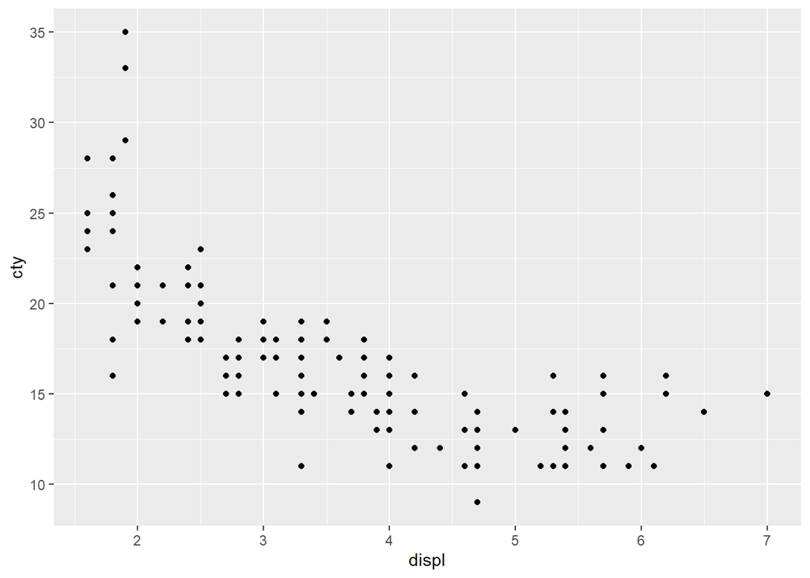

```r
mpg %>%
  ggplot(aes(x = displ, y = cty)) +
  geom_point()
```

**Question:** What is the relationship between `cty` and `displ`?  
**Solution:** The relationship is negative.

Produce a boxplot:

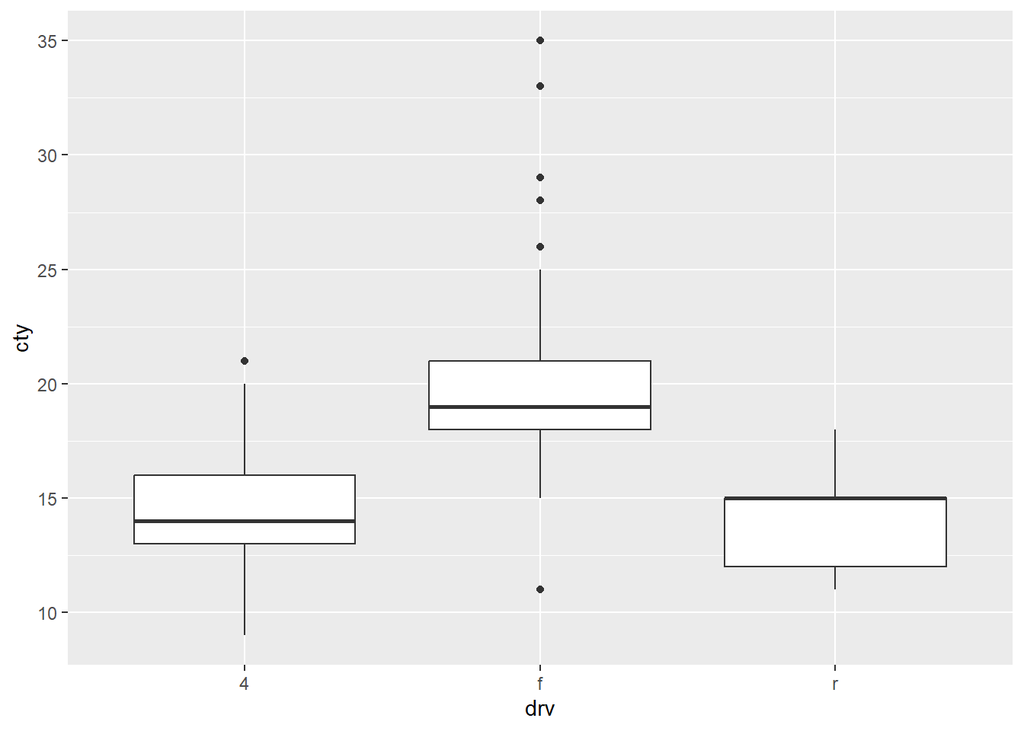

```r
mpg %>%
  ggplot(aes(y = cty, x = drv)) +
  geom_boxplot()
```

**Question:** Which level of `drv` has the highest city fuel efficiency?  
**Solution:** `drv = f` has the highest fuel efficiency.

Produce a scatterplot colored by `drv`:

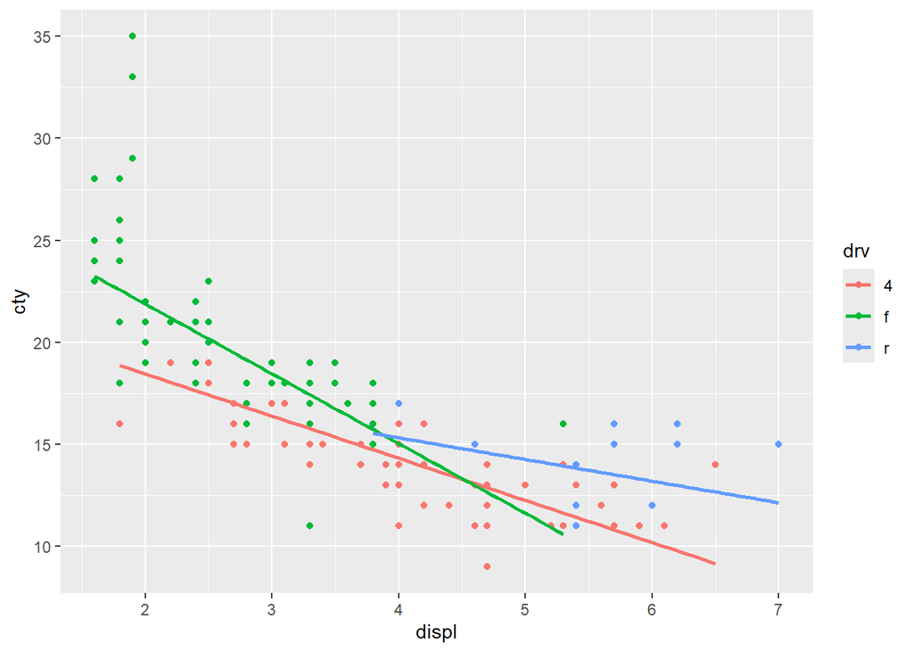

```r
mpg %>%
  ggplot(aes(x = displ, y = cty, colour = drv)) +
  geom_point() +
  geom_smooth(formula = y ~ x, method = lm, se = FALSE)
```

**Question:** Is there a relationship between `drv` and `displ` in predicting `cty`?  
**Solution:** Yes, there appears to be a relationship.

## ANOVA

Fit a linear regression model and perform a one-way ANOVA:

```r
lm1 <- lm(cty ~ drv, data = mpg)
anova(lm1)
```

```
## Analysis of Variance Table
##
## Response: cty
##            Df Sum Sq Mean Sq F value    Pr(>F)
## drv         2 1878.8  939.41  92.676 < 2.2e-16 ***
## Residuals 231 2341.5   10.14
## ---
## Signif. codes:  0 '***' 0.001 '**' 0.01 '*' 0.05 '.' 0.1 ' ' 1
```

**Question:** What is the observed value of the test statistic for the one-way ANOVA?  
**Solution:** $F = 92.676$

**Question:** What are the degrees of freedom?  
**Solution:** $df = 2, 231$

**Question:** Do you accept or reject $H_0$ at $\alpha = 0.05$?  
**Solution:** Reject $H_0$ as the p-value is less than 0.05.

## Identical Regressions Model

Fit a linear regression:

```r
lm2 <- lm(cty ~ displ, data = mpg)
summary(lm2)
```

```
##
## Call:
## lm(formula = cty ~ displ, data = mpg)
##
## Residuals:
##     Min      1Q  Median      3Q     Max
## -6.3109 -1.4695 -0.2566  1.1087 14.0064
##
## Coefficients:
##             Estimate Std. Error t value Pr(>|t|)
## (Intercept)  25.9915     0.4821   53.91   <2e-16 ***
## displ        -2.6305     0.1302  -20.20   <2e-16 ***
## ---
## Signif. codes:  0 '***' 0.001 '**' 0.01 '*' 0.05 '.' 0.1 ' ' 1
##
## Residual standard error: 2.567 on 232 degrees of freedom
## Multiple R-squared:  0.6376, Adjusted R-squared:  0.6361
## F-statistic: 408.2 on 1 and 232 DF,  p-value: < 2.2e-16
```

**Question:** What is the value of $\hat{\beta_0}$ (intercept)?  
**Solution:** $\hat{\beta_0} = 25.9915$

## Parallel Regressions Model

Fit a linear regression:

```r
lm3 <- lm(cty ~ displ + drv, data = mpg)
summary(lm3)
```

```
##
## Call:
## lm(formula = cty ~ displ + drv, data = mpg)
##
## Residuals:
##     Min      1Q  Median      3Q     Max
## -7.2377 -1.3423 -0.1424  1.0129 13.4884
##
## Coefficients:
##             Estimate Std. Error t value Pr(>|t|)
## (Intercept)  23.6796     0.6993  33.862  < 2e-16 ***
## displ        -2.3385     0.1652 -14.156  < 2e-16 ***
## drvf          2.2752     0.4009   5.676 4.14e-08 ***
## drvr          2.5045     0.5552   4.511 1.03e-05 ***
## ---
## Signif. codes:  0 '***' 0.001 '**' 0.01 '*' 0.05 '.' 0.1 ' ' 1
##
## Residual standard error: 2.332 on 230 degrees of freedom
## Multiple R-squared:  0.7035, Adjusted R-squared:  0.6996
## F-statistic: 181.9 on 3 and 230 DF,  p-value: < 2.2e-16
```

**Question:** What are the equations for the lines of best fit?  
**Solution:**  
- For `drv = 4`: $cty = 23.6796 - 2.3385 \cdot displ$  
- For `drv = f`: $cty = 25.9547 - 2.3385 \cdot displ$  
- For `drv = r`: $cty = 26.1841 - 2.3385 \cdot displ$

## Separate Regressions Model

Fit a regression model with interaction terms:

```r
lm4 <- lm(cty ~ displ * drv, data = mpg)
summary(lm4)
```

```
##
## Call:
## lm(formula = cty ~ displ * drv, data = mpg)
##
## Residuals:
##     Min      1Q  Median      3Q     Max
## -6.4363 -1.2957 -0.0863  1.1203 12.7768
##
## Coefficients:
##             Estimate Std. Error t value Pr(>|t|)
## (Intercept)  22.5914     0.8136  27.768  < 2e-16 ***
## displ        -2.0663     0.1958 -10.554  < 2e-16 ***
## drvf          6.1284     1.1632   5.269 3.18e-07 ***
## drvr         -3.0124     3.1043  -0.970 0.332872
## displ:drvf   -1.3529     0.3696  -3.661 0.000313 ***
## displ:drvr    1.0039     0.6048   1.660 0.098285 .
## ---
## Signif. codes:  0 '***' 0.001 '**' 0.01 '*' 0.05 '.' 0.1 ' ' 1
##
## Residual standard error: 2.252 on 228 degrees of freedom
## Multiple R-squared:  0.7261, Adjusted R-squared:  0.7201
## F-statistic: 120.9 on 5 and 228 DF,  p-value: < 2.2e-16
```

**Question:** What are the equations for the lines of best fit?  
**Solution:**  
- For `drv = 4`: $cty = 22.5914 - 2.0663 \cdot displ$  
- For `drv = f`: $cty = 28.7198 - 3.4193 \cdot displ$  
- For `drv = r`: $cty = 19.579 - 1.0624 \cdot displ$

## Model Selection

Compare models using AIC:

```r
AIC(lm2, lm3, lm4)
```

```
##     df      AIC
## lm2  3 1109.336
## lm3  5 1066.391
## lm4  7 1051.857
```

Compare models using BIC:

```r
BIC(lm2, lm3, lm4)
```

```
##     df      BIC
## lm2  3 1119.702
## lm3  5 1083.667
## lm4  7 1076.045
```

**Question:** Which model is preferred by AIC?  
**Solution:** The separate regressions model ($AIC = 1051.857$).

**Question:** Which model is preferred by BIC?  
**Solution:** The separate regressions model ($BIC = 1076.045$).

Predict `cty` for a car with 4.7L engine displacement and `drv = 4`:

```r
new_car <- data.frame(displ = 4.7, drv = "4")
predict(lm4, newdata = new_car)
```

```
##        1
## 12.87965
```

**Solution:** The predicted value of `cty` is 12.8797.